# Latent Growth Mixture Model Plots

Doug Tommet

2017-01-20

# Overview

After fitting a growth mixture model, we are often interested in the shape of the trajectories for the latent classes. This presentation shows how to create a figure that has the estimated tractery for each latent class. A similar figure is seen in *van de Schoot (2016)* (Figure 3). The figure is created in R using ggplot2.

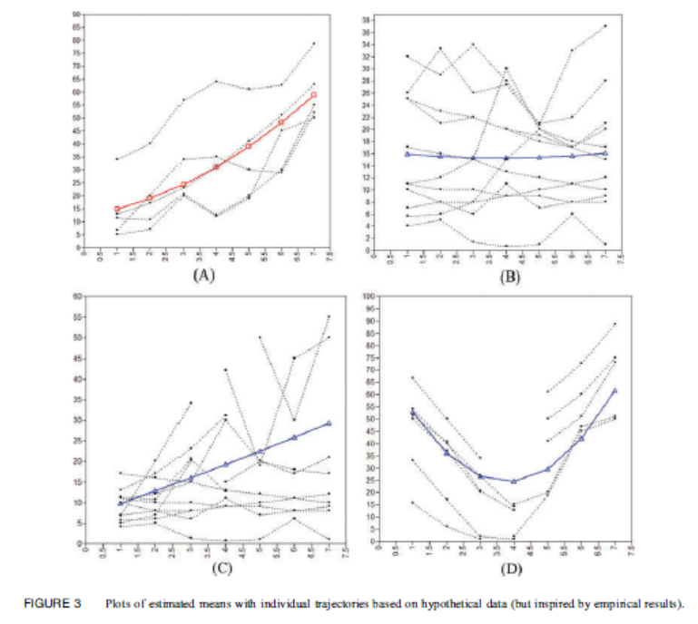

van de Schoot (2016): Figure 3

# Overview

This presentation will cover:

- Creating the data using Mplus monte carlo
- Reading the data into R
- Doing a quick exploratory analysis
- Fitting a growth mixture model in Mplus
- Using the results from the Mplus analysis to create a plot of trajectories by class.

**Update**

- Calculate fit indices

# Libraries and functions

These are the R libraries used in the presentation.

```r
library(plyr)
library(reshape)
library(dplyr)
library(ggplot2)
library(tidyr)
library(stringr)
library(MplusAutomation)
library(knitr)
```

This is a user written R function I found online because I can’t figure out some aspects of ggplot.

```r
# http://www.cookbook-r.com/Graphs/Multiple_graphs_on_one_page_(ggplot2)/
# Multiple plot function
#
# ggplot objects can be passed in ..., or to plotlist (as a list of ggplot objects)
# - cols:   Number of columns in layout
# - layout: A matrix specifying the layout. If present, 'cols' is ignored.
#
# If the layout is something like matrix(c(1,2,3,3), nrow=2, byrow=TRUE),
# then plot 1 will go in the upper left, 2 will go in the upper right, and
# 3 will go all the way across the bottom.
#
multiplot <- function(..., plotlist=NULL, file, cols=1, layout=NULL) {
  library(grid)

  # Make a list from the ... arguments and plotlist
  plots <- c(list(...), plotlist)

  numPlots = length(plots)

  # If layout is NULL, then use 'cols' to determine layout
  if (is.null(layout)) {
    # Make the panel
    # ncol: Number of columns of plots
    # nrow: Number of rows needed, calculated from # of cols
    layout <- matrix(seq(1, cols * ceiling(numPlots/cols)),
                    ncol = cols, nrow = ceiling(numPlots/cols))
  }

 if (numPlots==1) {
    print(plots[[1]])

  } else {
    # Set up the page
    grid.newpage()
    pushViewport(viewport(layout = grid.layout(nrow(layout), ncol(layout))))

    # Make each plot, in the correct location
    for (i in 1:numPlots) {
      # Get the i,j matrix positions of the regions that contain this subplot
      matchidx <- as.data.frame(which(layout == i, arr.ind = TRUE))

      print(plots[[i]], vp = viewport(layout.pos.row = matchidx$row,
                                      layout.pos.col = matchidx$col))
    }
  }
}
```

# Create Data

Since we don’t have original data to use in this example, we are going to simulate some data using Mplus’ Monte Carlo option.

I use the R package MplusAutomation to run Mplus through R. The function allows you to pass through most of Mplus’ options. However, one of the few options it doesn’t support is the Monte Carlo option.

To get around this, I created a standard Mplus input file in a text editor. I run this file in Mplus with the runModels() command.

**Note:** This will run all *.inp* files in the working directory.

The model simulates longitudinal data over six time points for 500 subjects. There are four latent classes.

```r
# gmm001.inp is the Mplus file that is created later in the presentation
# I am deleting it now so it doesn't get run here.
file.remove("gmm001.inp")
```

```
## [1] TRUE
```

```r
file.remove("gmm002.inp")
```

```
## [1] TRUE
```

```r
runModels()
```

```
##
## Running model: monte-carlo.inp
## System command: C:\Windows\system32\cmd.exe /c cd "S:\work\amphibian-lgmm" && "Mplus" "monte-carlo.inp"
```

# Read in the monte carlo data

If we have actual data to use, we could jump directly to this step and read in the data in the usual way.

MplusAutomation has a nice command to read in data created by Mplus. Otherwise you would need to do a command similar to the one commented out.

The growth mixture model in Mplus likes data in a “wide” format, where each measurement time is a new variable. The package ggplot likes data in a “long” format, where the measurements are stacked in one variable and another variable indicates when the measurement was taken.

This code takes the “wide” data file and converts it to “long”.

```r
data <- getSavedata_Data("monte-carlo.out")
colnames(data) <- tolower(names(data))

# data <- read.fwf(file="mcdata.dat", header=FALSE,
#                  widths = c(rep(13, 6), 3),
#                  col.names = c("y1", "y2", "y3", "y4", "y5", "y6", "c"))

# data currently in "wide" format
data <- data %>%
  mutate(id = row_number(),
         subsample = runif(nrow(.)))

# converting the data to "long" format
data.long <- data %>%
  gather(foo, y, y1:y6) %>%
  mutate(time = as.numeric(str_sub(foo, 2))) %>%
  arrange(id, time) %>%
  select(-foo)

head(data)
```

```
##          y1        y2        y3        y4        y5        y6 c id
## 1 10.648888 11.877818 12.655686 15.146736 17.713483 17.588851 4  1
## 2  7.950499  9.425913  8.590537 10.074895  9.289337 10.080144 2  2
## 3 12.371036 13.421617 17.478057 19.415944 22.843179 26.829369 4  3
## 4  1.968726  1.901051  0.513132  1.417859  3.821579  7.512429 3  4
## 5 10.623194 12.873786 15.352928 17.648866 20.551219 23.809973 4  5
## 6  9.836673 12.727578 15.644474 15.997809 19.392901 20.507929 4  6
##    subsample
## 1 0.20498881
## 2 0.83637210
## 3 0.08107692
## 4 0.39207563
## 5 0.89802360
## 6 0.42575032
```

```r
head(data.long, 18)
```

```
##    c id  subsample         y time
## 1  4  1 0.20498881 10.648888    1
## 2  4  1 0.20498881 11.877818    2
## 3  4  1 0.20498881 12.655686    3
## 4  4  1 0.20498881 15.146736    4
## 5  4  1 0.20498881 17.713483    5
## 6  4  1 0.20498881 17.588851    6
## 7  2  2 0.83637210  7.950499    1
## 8  2  2 0.83637210  9.425913    2
## 9  2  2 0.83637210  8.590537    3
## 10 2  2 0.83637210 10.074895    4
## 11 2  2 0.83637210  9.289337    5
## 12 2  2 0.83637210 10.080144    6
## 13 4  3 0.08107692 12.371036    1
## 14 4  3 0.08107692 13.421617    2
## 15 4  3 0.08107692 17.478057    3
## 16 4  3 0.08107692 19.415944    4
## 17 4  3 0.08107692 22.843179    5
## 18 4  3 0.08107692 26.829369    6
```

# Exploratory data analysis

This is just a simple plot to visualize the data. In a real analysis, you should do more.

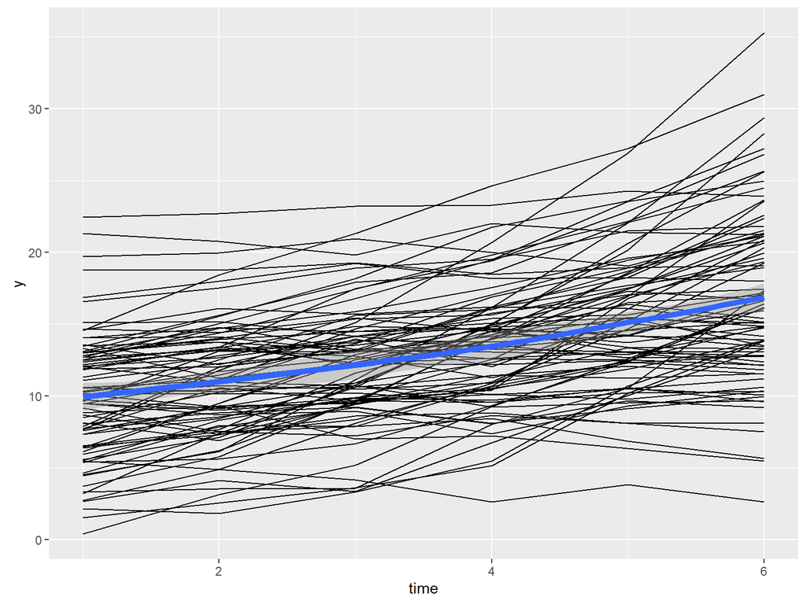

```r
data.long %>%
  filter(subsample <.2) %>%
  ggplot(aes(x=time, y=y, group=id)) +
    geom_line() +
    geom_smooth(aes(group = 1), size=2)
```

This is the plot we’d ideally like to have. However, with real data the true latent class variable is unknown.

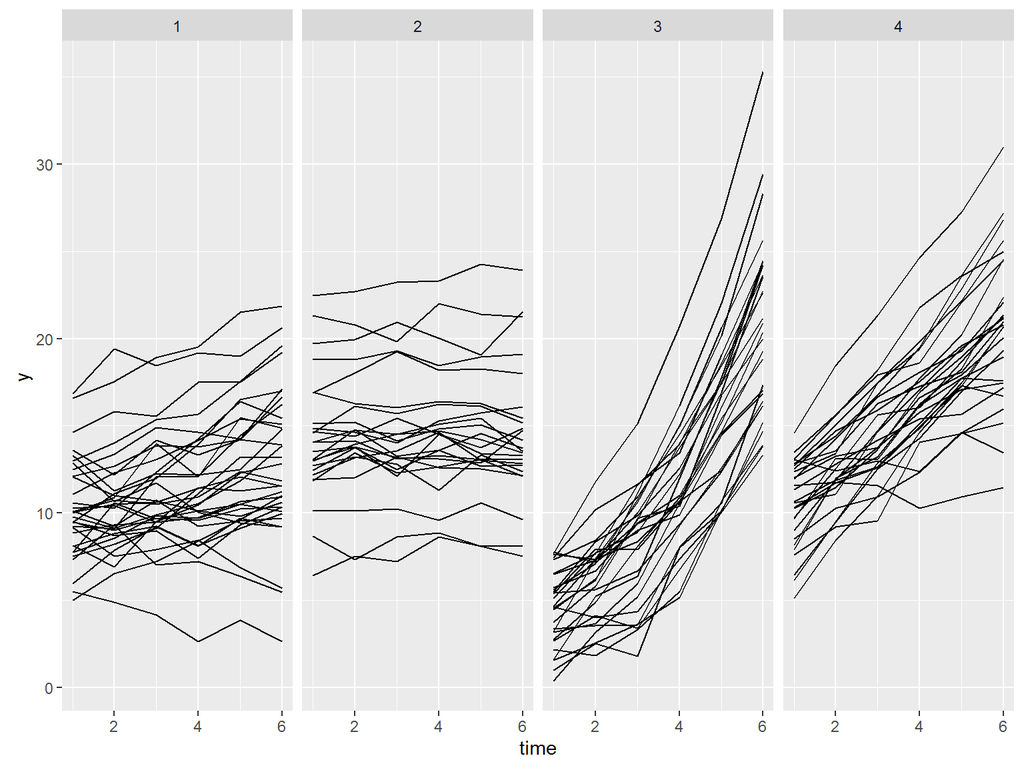

```r
# The variable c is the "true" latent class membership
data.long %>%
  filter(subsample <.25) %>%
  ggplot(aes(x=time, y=y, group=id)) +
    geom_line() +
    facet_grid(. ~c)
```

# Fit the growth mixture model in Mplus

This code fits a four class growth mixture model. The model assumes a linear trajectory with equally spaced time intervals.

```r
gmm.model.1 <- " %OVERALL%
                 i s | y1@0 y2@1 y3@2 y4@3 y5@4 y6@5 ;
               "
gmm.body <- mplusObject(
  ANALYSIS = "type=mixture; starts = 100 20;",
  VARIABLE = "classes = c(4); idvariable = id;",
  MODEL = gmm.model.1,
  OUTPUT = "",
  SAVEDATA = "save = cprob; file=model1prob.dat;",
  usevariables = c("id", "y1", "y2", "y3", "y4", "y5", "y6"),
  rdata = data
)
gmm.fit <- mplusModeler(gmm.body, modelout = "gmm001.inp", run = TRUE)
```

```
##
## Running model: gmm001.inp
## System command: C:\Windows\system32\cmd.exe /c cd "S:\work\amphibian-lgmm" && "Mplus" "gmm001.inp"
## Reading model:  gmm001.out
```

# Read in the saved class membership and parameter estimates

After fitting the model in Mplus, we need to get the results back into R.

This code reads in and saves the parameter estimates to an object called *param1*.

```r
# This is all the model parameters
param1 <- extractModelParameters("gmm001.out")$unstandardized
param1
```

```
##            paramHeader param    est    se  est_se    pval
## 1                  I.|    Y1  1.000 0.000 999.000 999.000
## 2                  I.|    Y2  1.000 0.000 999.000 999.000
## 3                  I.|    Y3  1.000 0.000 999.000 999.000
## 4                  I.|    Y4  1.000 0.000 999.000 999.000
## 5                  I.|    Y5  1.000 0.000 999.000 999.000
## 6                  I.|    Y6  1.000 0.000 999.000 999.000
## 7                  S.|    Y1  0.000 0.000 999.000 999.000
## 8                  S.|    Y2  1.000 0.000 999.000 999.000
## 9                  S.|    Y3  2.000 0.000 999.000 999.000
## 10                 S.|    Y4  3.000 0.000 999.000 999.000
## 11                 S.|    Y5  4.000 0.000 999.000 999.000
## 12                 S.|    Y6  5.000 0.000 999.000 999.000
## 13              S.WITH     I  0.171 0.101   1.697   0.090
## 14               Means     I 11.707 0.317  36.987   0.000
```

[output cut: 225 more lines]

```r
# Keeping only the parameters I'm interested in
param1 <- param1 %>%
  filter(grepl("Means", paramHeader)) %>%
  filter(!grepl("Categorical.Latent.Variables", LatentClass))
param1
```

```
##   paramHeader param    est    se est_se  pval LatentClass
## 1       Means     I 11.707 0.317 36.987 0.000           1
## 2       Means     S  0.171 0.054  3.173 0.002           1
## 3       Means     I  2.282 0.263  8.668 0.000           2
## 4       Means     S  3.486 0.086 40.408 0.000           2
## 5       Means     I 17.348 0.727 23.863 0.000           3
## 6       Means     S -0.059 0.049 -1.212 0.225           3
## 7       Means     I  9.261 0.277 33.402 0.000           4
## 8       Means     S  1.923 0.071 27.237 0.000           4
```

This code reads in the predicted class membership and merges it with the original data. It also recreates the “long” format of the data.

```r
foo <- getSavedata_Data("gmm001.out") %>%
  rename(model1.c = C) %>%
  select(ID, model1.c)
colnames(foo) <- tolower(names(foo))

# merging the predicted class membership into the "wide" data
data <- data %>%
  full_join(foo, by= "id" )

# recreating the "long" version of the data from the updated "wide" data
data.long <- data %>%
  gather(foo, y, y1:y6) %>%
  mutate(time = as.numeric(str_sub(foo, 2))) %>%
  arrange(id, time) %>%
  select(-foo)
```

# Plot the trajectories of the latent classes

This is my current working version of the code to create the plot. There were many other ways I tried, but all of them failed in some way. In the future, as I learn more about ggplot, I would like to revise this code.

The things I would like to change are:

- Currently, the parameter estimates need to be manually entered into the plotting function. This breaks the rules of reproducibility. Every time we change the model, the paraameter estimates would need to be reentered.
- Get the ggplot functions *facet_grid* and *stat_function* to work nicely together. Then we can avoid creating individual plots for each class and then combining them.

Create the functions to be plotted for each latent class

```r
param1.matrix <- param1 %>%
  select(param, est, LatentClass) %>%
  spread(param, est) %>%
  select(-LatentClass)
param1.matrix
```

```
##        I      S
## 1 11.707  0.171
## 2  2.282  3.486
## 3 17.348 -0.059
## 4  9.261  1.923
```

```r
fun.1 <- function(x) 11.707 + 0.171*x
fun.2 <- function(x)  2.282 + 3.486*x
fun.3 <- function(x) 17.348 - 0.059*x
fun.4 <- function(x)  9.261 + 1.923*x
```

Since we’re going to be creating the same plot multiple times, we can put it in a function so that it would be easier to edit in the future.

```r
# Creating my own function to do the individual plots.
# a is the class number
# f is the corresponding function to be plotted
myplot <- function(a, f) {
  data.long %>%
  filter(subsample <.25) %>%
  filter(model1.c==a) %>%
    ggplot(aes(x=time, y=y, group=id)) +
      scale_y_continuous(limits = c(0, 30)) +
      geom_line() +
      stat_function(fun = f, color="blue", size=2) +
      ggtitle(paste("class", a))

}
plot1 <- myplot(1, fun.1)
plot2 <- myplot(2, fun.2)
plot3 <- myplot(3, fun.3)
plot4 <- myplot(4, fun.4)
```

Combine the plots into one using code found online.

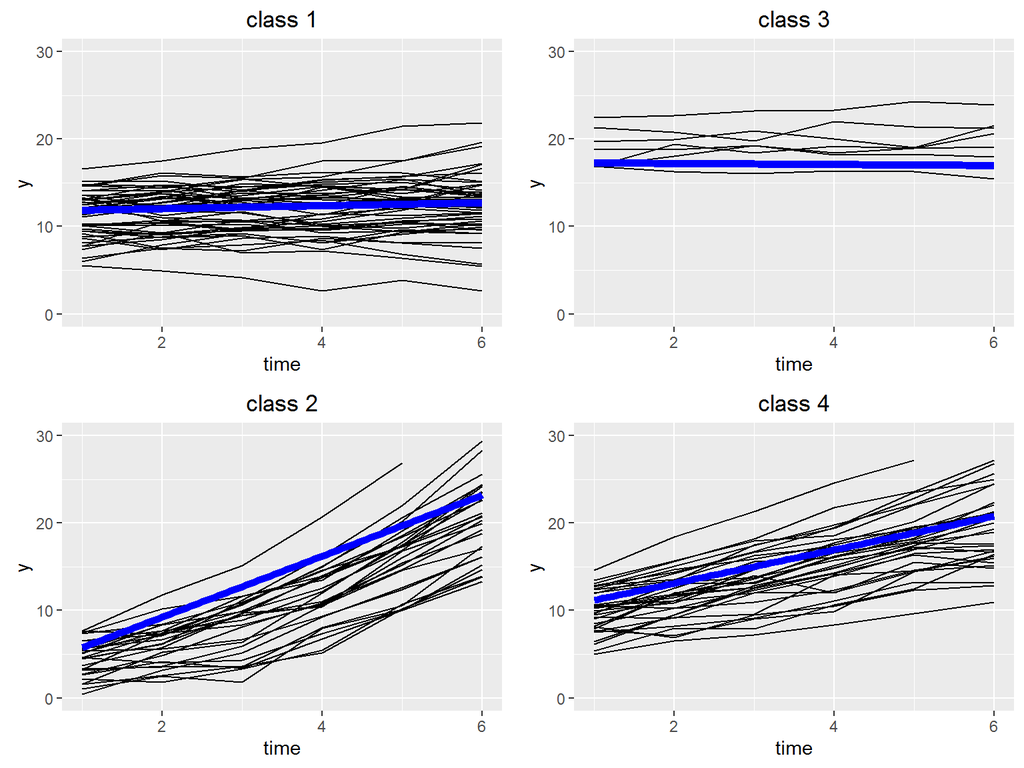

```r
# This is the function listed in "001-libraries-and-functions.Rmd"
multiplot(plotlist = list(plot1, plot2, plot3, plot4), cols = 2)
```

Clean up the plots with code provided by David Barker

```r
mytheme<-  theme(panel.background = element_blank(),
                 axis.title.x     = element_text(vjust=-.25,
                                      size=18, face="bold"),
                 axis.title.y     = element_text(vjust=1.25,
                                      size=18, face="bold"),
                 axis.text        = element_text(size=18),
                 axis.line        = element_line(colour="black"),
                 panel.grid.minor = element_blank(),
                 panel.grid.major = element_line(colour="grey90"),
                 legend.background = element_blank(),
                 legend.title      = element_text(size=12),
                 legend.text       = element_text(size=12),
                 legend.key        = element_blank(),
                 legend.key.size   = unit(1.5, "lines"),
                 legend.key.width  = unit(1, "lines"))
#legend.position="none")

# This function only differs by the addition of "mytheme"
dbplot <- function(a, f) {
  data.long %>%
  filter(subsample <.25) %>%
  filter(model1.c==a) %>%
    ggplot(aes(x=time, y=y, group=id)) +
      scale_y_continuous(limits = c(0, 30)) +
      geom_line() +
      stat_function(fun = f, color="blue", size=2) +
      ggtitle(paste("class", a)) +
      mytheme

}
plot1 <- dbplot(1, fun.1)
plot2 <- dbplot(2, fun.2)
plot3 <- dbplot(3, fun.3)
plot4 <- dbplot(4, fun.4)
```

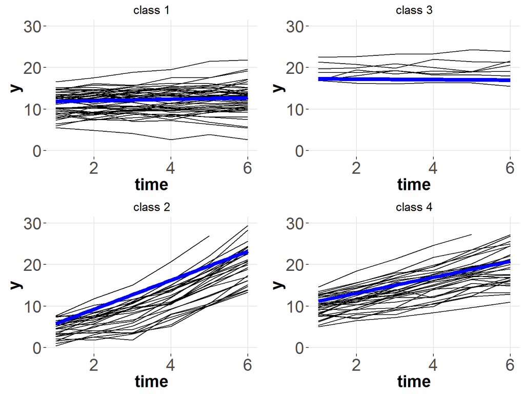

```r
multiplot(plotlist = list(plot1, plot2, plot3, plot4), cols = 2)
```

# Fit the a different growth mixture model in Mplus

This code fits a three class growth mixture model. The model assumes a quadratic trajectory with equally spaced time intervals.

The other code chunks are similar to the previous slide.

```r
gmm.model.2 <- " %OVERALL%
                 i s q| y1@0 y2@1 y3@2 y4@3 y5@4 y6@5 ;
               "
gmm.body <- mplusObject(
  ANALYSIS = "type=mixture; starts = 100 20;",
  VARIABLE = "classes = c(3); idvariable = id;",
  MODEL = gmm.model.2,
  OUTPUT = "",
  SAVEDATA = "save = cprob; file=model1prob.dat;",
  usevariables = c("id", "y1", "y2", "y3", "y4", "y5", "y6"),
  rdata = data
)
gmm.fit <- mplusModeler(gmm.body, modelout = "gmm002.inp", run = TRUE)
```

```
##
## Running model: gmm002.inp
## System command: C:\Windows\system32\cmd.exe /c cd "S:\work\amphibian-lgmm" && "Mplus" "gmm002.inp"
## Reading model:  gmm002.out
```

```r
param2 <- extractModelParameters("gmm002.out")$unstandardized %>%
  filter(grepl("Means", paramHeader)) %>%
  filter(!grepl("Categorical.Latent.Variables", LatentClass))
```

```r
foo <- getSavedata_Data("gmm002.out") %>%
  rename(model2.c = C) %>%
  select(ID, model2.c)
colnames(foo) <- tolower(names(foo))

data <- data %>%
  full_join(foo, by= "id" )

data.long <- data %>%
  gather(foo, y, y1:y6) %>%
  mutate(time = as.numeric(str_sub(foo, 2))) %>%
  arrange(id, time) %>%
  select(-foo)
```

# Plot the trajectories of the latent classes from the second model

Create the functions to be plotted for each latent class

```r
param2.matrix <- param2 %>%
  select(param, est, LatentClass) %>%
  spread(param, est) %>%
  select(-LatentClass)
param2.matrix
```

```
##        I      Q     S
## 1  9.721  0.009 1.919
## 2 12.670 -0.007 0.191
## 3  4.403  0.514 0.783
```

```r
fun.1 <- function(x)  9.721 + 1.919*x + 0.009*x^2
fun.2 <- function(x) 12.670 + 0.191*x - 0.007*x^2
fun.3 <- function(x)  4.403 + 0.783*x + 0.514*x^2
```

Note: In this set of plots I am including a loess smooth line in addition to the estimated trajectory.

```r
myplot2 <- function(x, f) {
  data.long %>%
  filter(subsample <.25) %>%
  filter(model2.c==x) %>%
    ggplot(aes(x=time, y=y, group=id)) +
      scale_y_continuous(limits = c(0, 30)) +
      geom_line() +
      stat_function(fun = f, color="blue", size=2) +
      geom_smooth(aes(group=1), color="red") +
      ggtitle(paste("class", x))

}
plot1 <- myplot2(1, fun.1)
plot2 <- myplot2(2, fun.2)
plot3 <- myplot2(3, fun.3)
```

Combine the plots into one.

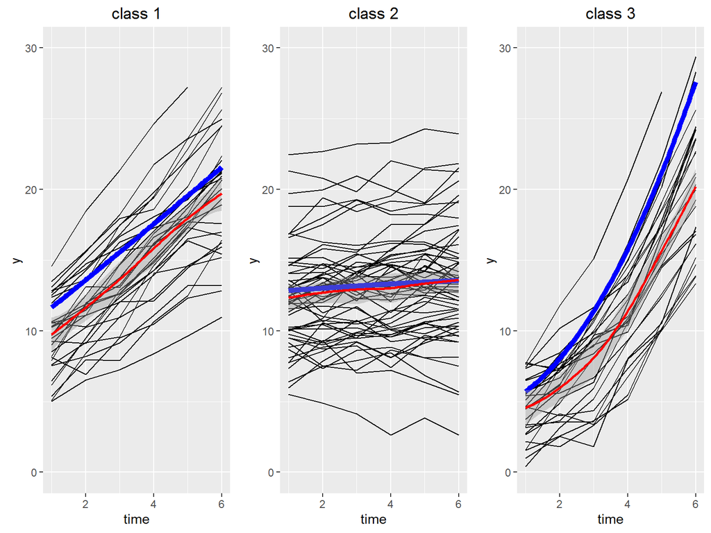

```r
multiplot(plotlist = list(plot1, plot2, plot3), cols = 3)
```

# Calculate Fit Indices

This is code to calculate fit indices provided by David Barker.

```r
#code that calculates fit indices from latent class models
# Assumes the models were run in Mplus, that the MplusAutomation package is installed,
# and that the output files for the various enumeration models are saved in the same folder as the
# current RStudio working directory.
##########RELATIVE FIT INDICIES##############
#BIC=-2LL+dlog(n)
#CAIC = -2LL+d[log(n)+1]
#AWE = -2LL+2d[log(n)+1.5]
#Bayes Factor = exp[SICa-SICb]~Pr(Model A correct)/Pr(Model B correct)
#SIC=-.5BIC
#correct model probability cmP = exp(SICa-SICmax)/SUM(exp(SICj-SICmax))

# Use a regular expression to get Mplus output files that you want to read in
mplus.files <- dir(pattern = "gmm.*\\.out")
sum_stat <- extractModelSummaries(target = mplus.files, recursive = F)
sum_stat <- sum_stat[!is.na(sum_stat$Parameters),]
sum_stat$model <- as.numeric(gsub("m1c|[^[:digit:]]","",sum_stat$Filename))
sum_stat<-sum_stat[order(sum_stat$model),]

sum_stat <- transform(sum_stat,
                      CAIC = -2*LL+Parameters*(log(Observations)+1),
                      AWE = -2*LL+2*Parameters*(log(Observations)+1.5),
                      SIC = -.5*BIC)
sum_stat$by <- 1
#SICmax <- aggregate(sum_stat$SIC, list(by=sum_stat$by), FUN=max, simplify = T)
SICmax <- aggregate(SIC ~ by, data = sum_stat, max, simplify = T)
SICmax <- plyr::rename(SICmax, c("SIC"="SICmax"))
sum_stat <-merge(sum_stat, SICmax, by="by")
sum_stat <- transform(sum_stat, exp_d_SIC = exp(SIC-SICmax))
exp_d_SIC_sum <- aggregate(exp_d_SIC ~ by, data = sum_stat, FUN="sum", simplify = T)
exp_d_SIC_sum <- plyr::rename(exp_d_SIC_sum, c("exp_d_SIC"="exp_d_SIC_sum"))
sum_stat <-merge(sum_stat, exp_d_SIC_sum, by="by")
sum_stat <- transform(sum_stat, cmP = exp_d_SIC/exp_d_SIC_sum)

sum_stat$SIC_lag <- c(tail(sum_stat$SIC, -1),NA)
sum_stat <- transform(sum_stat, BF_k_vs_kp1 = exp(SIC-SIC_lag))
#minimum sample size

class.n<-matrix(nrow=nrow(sum_stat), ncol=2)
colnames(class.n)<-c("model","min_class_size")
for (i in 1:nrow(sum_stat)){
  class.counts<-readModels(target = mplus.files[i],
                           recursive = FALSE)$class_counts$posteriorProb
  class.n[i,]<-c(i,round(min(class.counts$count),0))
}
```

```
## Reading model:  gmm001.out
## Reading model:  gmm002.out
```

```r
sum_stat<-merge(sum_stat, class.n, by="model",all=T)
sum_stat<-subset(sum_stat, select=c("Entropy", "LL", "Parameters", "BIC",
                                    "CAIC", "AWE", "cmP", "BF_k_vs_kp1",
                                    "min_class_size",
                                    "model"))
#"T11_VLMR_PValue",

## Why isn't kable working?
# kable(sum_stat)
sum_stat
```

```
##   Entropy        LL Parameters      BIC     CAIC     AWE           cmP
## 1   0.813 -5991.710         20 12107.71 12127.71 12292.0 1.740825e-204
## 2   0.866 -5513.214         23 11169.36 11192.36 11381.3  1.000000e+00
##     BF_k_vs_kp1 min_class_size model
## 1 1.740825e-204             50     1
## 2            NA            111     2
```

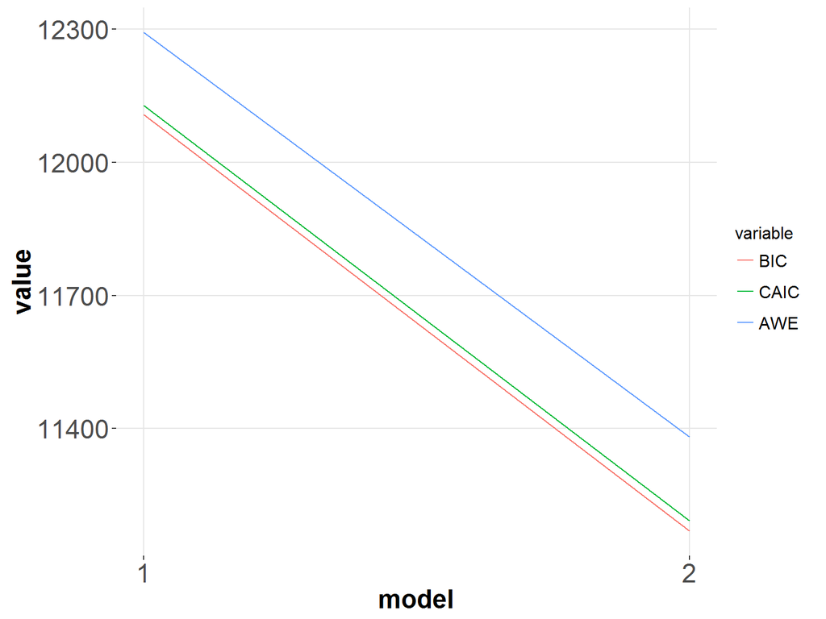

```r
m.sum_stat<-subset(melt(sum_stat,id="model"),
                   variable %in% c("BIC","CAIC","AWE"), model:value)
ggplot(m.sum_stat, aes(model, value, colour=variable)) +
  geom_line() +
  scale_x_continuous(breaks = seq(1, 10, 1)) +
  mytheme
```

# Mplus file

This is the Mplus file used to create the data

```r
cat(readLines('monte-carlo.inp'), sep = '\n')
```

```
montecarlo:
    names are y1-y6 ;
    genclasses = c(4);
    classes = c(2);
    nobs = 500;
    seed = 3454367;
    nrep = 1;
    save = mcdata.dat;

analysis:
    type = mixture;

model population:
    %overall%
    ![x@0]; !x@1;
    y1-y6*.5;
    i s q| y1@0 y2@1 y3@2 y4@3 y5@4 y6@5;
    i*1; s*.5; q*.01;
    !c#1 on x*1;
    !i on x*.5;
    !s on x*.3;
    !q on x*.2;

    %c#1%
    [i*10 s*.5 q*0];
    i*5;
    q*0;

    %c#2%
    [i*15 s*0 q*0];
    i*10
    s*0;
    q*0;

        %c#3%
        [i*5 s*1 q*.5];
        i*5
        q*.01;

        %c#4%
        [i*10 s*2 q*0];
        i*5
        q*0;
model:
    %overall%
    y1-y6*.5;
    i s | y1@0 y2@1 y3@2 y4@3 y5@4 y6@5;
    i*1; s*.2;
    !c#1 on x*1;
    !i on x*.5;
    !s on x*.3;
```